# Clima do Brasil — Supervisionado vs Não-Supervisionado

PCA · Random Forest · Ensemble · STL · Clustering · Open-Meteo ERA5

Author

Aprendizado de Máquina 2 — Insper

Published

May 22, 2026

**Ver código**

```r
library(tidyverse)
library(jsonlite)
library(GGally)
library(factoextra)
library(FactoMineR)
library(cluster)
library(patchwork)
library(tsibble)
library(fable)
library(feasts)
library(fabletools)
library(ranger)
library(doParallel)
library(plotly)
```

# 1 Introdução

Este relatório unifica dois modelos para a disciplina Aprendizado de Máquina II aplicados a **dados climáticos reais do Brasil**.

## 1.1 O Desafio dos Dados Climáticos

Dados climáticos são amplamente utilizados na construção de modelos preditivos e analíticos. Entretanto, existem desafios distintos e extremamente relevantes nesse domínio — em particular, a diferença entre **dados observacionais** (medições de estações meteorológicas, satélites e boias oceânicas) e **dados de previsão** (saídas de modelos numéricos que simulam a atmosfera para o futuro). Além disso, diferentes provedores disponibilizam dados com características, resoluções e coberturas distintas:

[output not shown]

A distinção entre reanálise e previsão é fundamental: **reanálises** (ERA5, MERRA-2) usam todas as observações disponíveis para reconstruir o estado passado da atmosfera — são os dados mais confiáveis para análise histórica, mas não estão disponíveis em tempo real. **Previsões operacionais** (IFS, GFS) projetam o estado futuro da atmosfera a partir de condições iniciais, com incerteza que cresce a cada hora de horizonte.

## 1.2 Importância Setorial do Monitoramento Climático

O monitoramento e a modelagem do clima são realizados por diversos institutos governamentais (INMET, INPE/CPTEC no Brasil; NOAA, NASA nos EUA; ECMWF na Europa), empresas privadas e institutos de pesquisa. A relevância desses dados permeia setores estratégicos da economia:

- **Agricultura:** previsões de precipitação e temperatura orientam decisões de plantio, irrigação, aplicação de defensivos e colheita. Safras inteiras dependem de janelas climáticas — uma geada não prevista pode destruir uma safra de café, e a previsão sazonal determina o planejamento da segunda safra de milho. No Brasil, o agronegócio representa cerca de 25% do PIB, tornando a previsão climática um insumo econômico de primeira ordem.
- **Empresas petrolíferas e de energia:** operações offshore (plataformas, FPSOs) dependem de previsões de vento e ondas para planejamento de operações de carga e logística marítima. Parques eólicos e solares precisam de estimativas precisas de recurso energético (radiação, velocidade do vento) para dimensionamento e para comercialização de energia no mercado spot. A reanálise ERA5 é amplamente usada para estimar o potencial eólico/solar em estudos de viabilidade.
- **Mineração:** atividades a céu aberto são diretamente impactadas por chuvas intensas que paralisam operações, comprometem a estabilidade de barragens de rejeitos e inviabilizam transporte em estradas de terra. A previsão de precipitação acumulada é crítica para gestão de risco operacional e ambiental.
- **Portuária e navegação:** a profundidade do calado em portos fluviais (como o de Manaus) depende do regime de chuvas e do nível dos rios — previsões sazonais orientam a logística de grandes cargueiros. Portos marítimos dependem de previsões de maré, vento e ondas para operações de atracação e carga.

## 1.3 Ensembles em Modelos Climáticos

Uma das técnicas mais poderosas em meteorologia e aprendizado de máquina é o uso de **ensembles** — a combinação de múltiplos modelos ou múltiplas execuções de um mesmo modelo para gerar previsões mais robustas.

Na meteorologia operacional, o conceito de ensemble é empregado de duas formas complementares:

1. **Ensemble de perturbações iniciais (multi-member):** o mesmo modelo numérico (por exemplo, o IFS do ECMWF) é executado múltiplas vezes com pequenas perturbações nas condições iniciais. Como a atmosfera é um sistema caótico, pequenas diferenças nas condições iniciais amplificam-se ao longo do tempo. Os 51 membros do ensemble IFS capturam essa sensibilidade e produzem uma **distribuição de previsões** — o spread entre os membros quantifica a incerteza. Quando os membros convergem, a confiança é alta; quando divergem, o cenário é incerto.
2. **Multi-model ensemble:** previsões de modelos diferentes (GFS, IFS, GEM canadense, ICON alemão) são combinadas — tipicamente por média ponderada, onde os pesos podem ser calibrados historicamente. A literatura mostra consistentemente que a média de múltiplos modelos supera qualquer modelo individual, porque cada um tem vieses sistemáticos diferentes que tendem a se cancelar na combinação.

Neste projeto, aplicamos o princípio de ensemble no contexto de aprendizado de máquina supervisionado: combinamos uma **Regressão Linear** (modelo paramétrico, alto viés, baixa variância) com um **Random Forest** (modelo não-paramétrico, baixo viés, alta variância). A média das previsões dos dois modelos tende a reduzir o erro total, pois os modelos tipicamente erram em dias diferentes e em direções opostas. A redução de erro segue a desigualdade:

$$\text{MSE}_{\text{ensemble}} \leq \frac{1}{K}\sum_{k=1}^K \text{MSE}_k$$

A igualdade só vale quando todos os modelos cometem exatamente os mesmos erros — cenário improvável quando os modelos têm estruturas distintas. Essa é a mesma lógica que torna o multi-model ensemble meteorológico superior a qualquer modelo individual.

## 1.4 Estrutura do Projeto

O desafio deste projeto é utilizar uma **base de dados unificada** para construir no mínimo dois modelos: um de **aprendizado supervisionado** e outro **não-supervisionado**. Toda a análise utiliza uma **fonte única de dados: Open-Meteo ERA5 Reanalysis**, garantindo consistência metodológica entre as partes.

|  | **Parte I — Supervisionado** | **Parte II — Não-Supervisionado** |
| --- | --- | --- |
| **Dados** | Open-Meteo ERA5 — São Paulo (diário) | Open-Meteo ERA5 — 12 cidades (diário → mensal) |
| **Granularidade** | Diária | Mensal (agregação) |
| **Alvo** | Temperatura de amanhã (`lead`) | Nenhum — descoberto |
| **Modelos** | LM · RF · Ensemble · Quantile RF | PCA · K-Means · STL · ARIMA · ETS |
| **Métrica** | RMSE · MAE · R² | Variância explicada · RMSE de forecast |

A pergunta central de cada parte é diferente:

- **Supervisionado:** *“Consigo prever a temperatura de amanhã com base nos padrões de hoje?”*
- **Não-supervisionado:** *“Existem zonas climáticas naturais no Brasil? Qual estrutura temporal caracteriza cada cidade?”*

Além disso, investigamos duas questões complementares:

- **Aquecimento:** *“São Paulo está esquentando ao longo dos anos?”*
- **Dinâmica dos clusters:** *“As zonas climáticas estão mudando ao longo do tempo?”*

# 2 Parte I — Abordagem Supervisionada

## 2.1 Dados — Open-Meteo (ERA5, São Paulo, Diário)

### 2.1.1 Carregamento dos Dados

Os dados foram pré-coletados do **Open-Meteo ERA5** via o script `fetch_data.py` e salvos localmente. A série cobre São Paulo de 1980 a 2024 com 6 variáveis diárias — 45 anos de histórico (era pós-satélite, quando a qualidade da reanálise ERA5 se torna substancialmente mais confiável).

**Tip**

**Para atualizar os dados**, execute `python fetch_data.py` no terminal. O script busca dados do Open-Meteo ERA5 em **janelas de 2 anos** por cidade, salvando cada chunk individualmente em `data/chunks/`. Pode ser interrompido a qualquer momento (Ctrl+C) e re-executado — chunks já baixados são pulados automaticamente. Ao final, combina tudo em `data/sp_daily.csv` e `data/brazil_monthly.csv`, reportando quais cidades foram carregadas com sucesso.

Flags adicionais:

- `python fetch_data.py --combine` — apenas recombina os chunks existentes nos CSVs finais (sem novas requisições).
- `python fetch_data.py --clean` — limpa cache (`data/chunks/`) e CSVs e recomeça do zero.

**Ver código**

```r
n_cores <- max(1L, parallel::detectCores() - 1L)
cl      <- makeCluster(n_cores)
registerDoParallel(cl)

weather_df <- read_csv("data/sp_daily.csv", show_col_types = FALSE) |>
  mutate(date = as.Date(date))

cat("Registros:", nrow(weather_df),
    "| Período:", format(min(weather_df$date)),
    "→", format(max(weather_df$date)), "\n")
```

```
Registros: 16437 | Período: 1980-01-01 → 2024-12-31
```

**Ver código**

```r
glimpse(weather_df)
```

```
Rows: 16,437
Columns: 7
$ date      <date> 1980-01-01, 1980-01-02, 1980-01-03, 1980-01-04, 1980-01-05,…
$ temp_max  <dbl> 19.0, 21.4, 23.0, 23.6, 23.7, 27.0, 28.6, 27.1, 26.9, 24.6, …
$ temp_min  <dbl> 15.9, 14.1, 14.4, 12.3, 13.6, 15.6, 18.1, 19.7, 19.4, 20.0, …
$ temp_mean <dbl> 17.1, 17.3, 18.2, 17.9, 18.6, 21.0, 23.4, 22.4, 21.9, 21.8, …
$ precip    <dbl> 4.1, 0.2, 0.0, 0.0, 0.0, 0.0, 0.0, 3.4, 12.6, 12.5, 19.1, 10…
$ wind_max  <dbl> 17.8, 16.3, 14.9, 15.1, 17.1, 13.8, 18.0, 12.1, 17.4, 21.9, …
$ radiation <dbl> 8.65, 23.52, 30.71, 31.92, 28.68, 28.00, 25.70, 13.95, 19.63…
```

### 2.1.2 Estrutura do Dataset

| Coluna | Unidade | Descrição |
| --- | --- | --- |
| `date` | — | Data (1980-01-01 a 2024-12-31) |
| `temp_max` | °C | Temperatura máxima diária |
| `temp_min` | °C | Temperatura mínima diária |
| `temp_mean` | °C | Temperatura média diária |
| `precip` | mm | Precipitação acumulada no dia |
| `wind_max` | km/h | Velocidade máxima do vento (10m) |
| `radiation` | MJ/m² | Radiação solar de ondas curtas |

## 2.2 Análise Exploratória

### 2.2.1 Séries de temperatura

**Ver código**

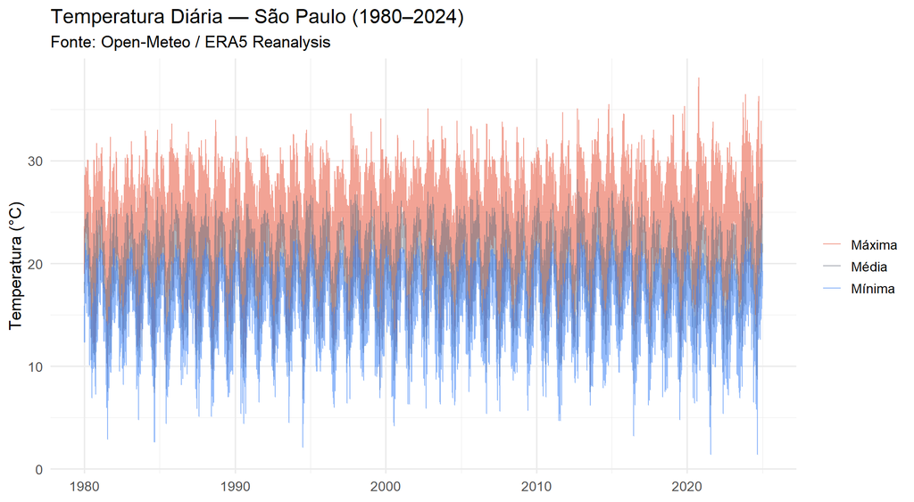

Figure 1: Temperatura diária de São Paulo (1980–2024). O ciclo sazonal anual é claro — verão (dez–mar) com picos acima de 30°C, inverno (jun–ago) com mínimas abaixo de 10°C.

```r
weather_df |>
  select(date, temp_max, temp_min, temp_mean) |>
  pivot_longer(-date, names_to = "serie", values_to = "valor") |>
  ggplot(aes(date, valor, color = serie)) +
  geom_line(alpha = 0.55, linewidth = 0.4) +
  scale_color_manual(
    values = c(temp_max = "#E8583E", temp_mean = "#6B7280", temp_min = "#3B82F6"),
    labels = c("Máxima", "Média", "Mínima")
  ) +
  labs(title    = "Temperatura Diária — São Paulo (1980–2024)",
       subtitle = "Fonte: Open-Meteo / ERA5 Reanalysis",
       x = NULL, y = "Temperatura (°C)", color = NULL) +
  theme_minimal(base_size = 13)
```

### 2.2.2 Sazonalidade mensal e correlações

**Ver código**

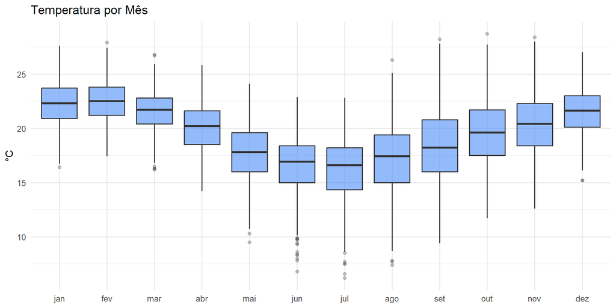

```r
p_box <- weather_df |>
  mutate(mes = month(date, label = TRUE)) |>
  ggplot(aes(mes, temp_mean)) +
  geom_boxplot(fill = "#3B82F6", alpha = 0.55, outlier.alpha = 0.3) +
  labs(title = "Temperatura por Mês", x = NULL, y = "°C") +
  theme_minimal(base_size = 12)

p_box
```

**Ver código**

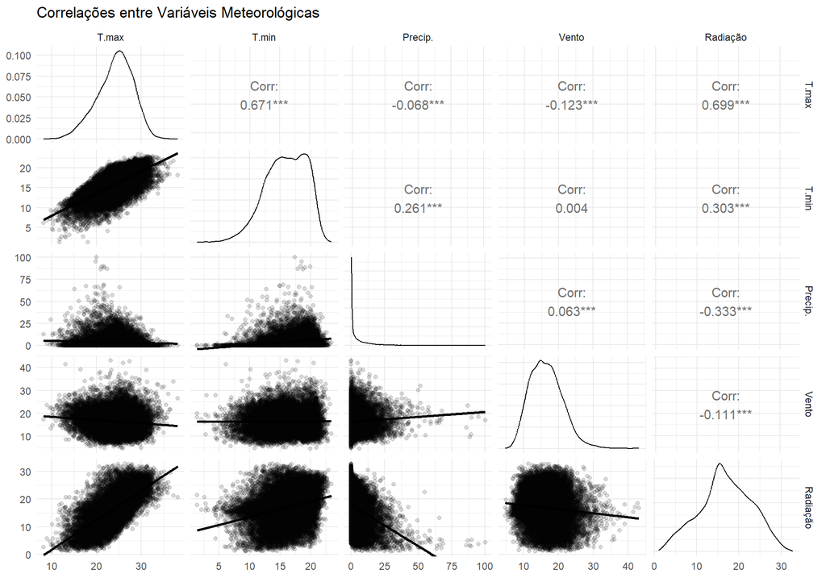

Figure 2: Matriz de correlação entre as 5 features. A alta correlação temp_max × temp_min justifica o uso de PCA — componentes ortogonais eliminam redundância e reduzem multicolinearidade.

```r
weather_df |>
  select(temp_max, temp_min, precip, wind_max, radiation) |>
  ggpairs(
    columnLabels = c("T.max", "T.min", "Precip.", "Vento", "Radiação"),
    lower  = list(continuous = wrap("smooth", alpha = 0.15)),
    upper  = list(continuous = wrap("cor", size = 4)),
    title  = "Correlações entre Variáveis Meteorológicas"
  ) +
  theme_minimal(base_size = 11)
```

## 2.3 Split Cronológico — Treino / Teste

**Warning**

**Regra inegociável em séries temporais:** nunca usar split aleatório. Dados futuros no treino causam **data leakage** — o modelo “vê o futuro” e produz métricas artificialmente boas que não se traduzem em produção.

**Ver código**

```r
cutoff <- as.Date("2023-01-01")

train_raw <- weather_df |> filter(date <  cutoff)
test_raw  <- weather_df |> filter(date >= cutoff)

cat(sprintf("Treino: %d dias | %s → %s\n",
            nrow(train_raw), min(train_raw$date), max(train_raw$date)))
```

```
Treino: 15706 dias | 1980-01-01 → 2022-12-31
```

**Ver código**

```r
cat(sprintf("Teste:  %d dias | %s → %s\n",
            nrow(test_raw),  min(test_raw$date),  max(test_raw$date)))
```

```
Teste:  731 dias | 2023-01-01 → 2024-12-31
```

## 2.4 Escala com Estatísticas do Treino

Média e desvio-padrão são calculados **exclusivamente no treino** e aplicados ao teste. Usar estatísticas do dataset completo vazaria informação do período de teste para o escalonamento do treino.

**Ver código**

```r
feature_cols <- c("temp_max", "temp_min", "precip", "wind_max", "radiation")

scale_center <- colMeans(train_raw[feature_cols])
scale_sd     <- apply(train_raw[feature_cols], 2, sd)

X_train <- scale(train_raw[feature_cols], center = scale_center, scale = scale_sd)
X_test  <- scale(test_raw[feature_cols],  center = scale_center, scale = scale_sd)

data.frame(Media = round(scale_center, 2), DP = round(scale_sd, 2)) |>
  knitr::kable(caption = "Parâmetros de escala — calculados apenas no treino")
```

Parâmetros de escala — calculados apenas no treino

|  | Media | DP |
| --- | --- | --- |
| temp_max | 24.10 | 3.99 |
| temp_min | 15.89 | 3.33 |
| precip | 3.62 | 6.90 |
| wind_max | 16.42 | 4.60 |
| radiation | 16.81 | 6.12 |

## 2.5 PCA — Ajustado no Treino, Aplicado no Teste

**Ver código**

```r
pca_sup <- prcomp(X_train, center = FALSE, scale. = FALSE)

cat("Variância acumulada por componente:\n")
```

```
Variância acumulada por componente:
```

**Ver código**

```r
var_exp <- cumsum(pca_sup$sdev^2) / sum(pca_sup$sdev^2)
print(round(var_exp, 4))
```

```
[1] 0.4338 0.6962 0.8877 0.9672 1.0000
```

**Ver código**

```r
cat("\nMatriz de Cargas (Phi):\n")
```

```
Matriz de Cargas (Phi):
```

**Ver código**

```r
print(round(pca_sup$rotation, 3))
```

```
             PC1    PC2    PC3    PC4    PC5
temp_max   0.643  0.069 -0.035 -0.008 -0.762
temp_min   0.497  0.484 -0.019  0.556  0.458
precip    -0.095  0.778  0.245 -0.571 -0.015
wind_max  -0.149  0.239 -0.956 -0.058 -0.060
radiation  0.555 -0.315 -0.157 -0.601  0.454
```

**Ver código**

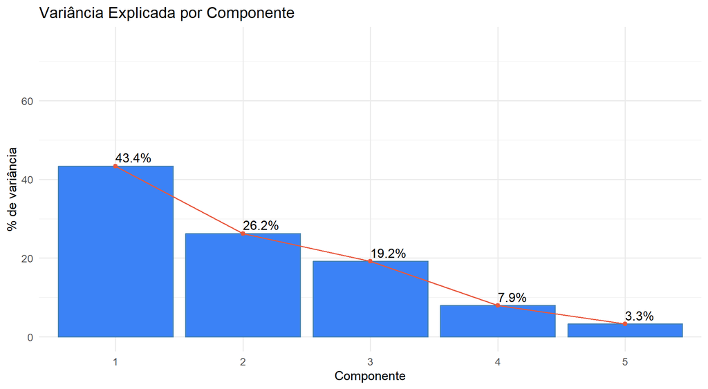

```r
fviz_eig(pca_sup, addlabels = TRUE, ylim = c(0, 75),
         barfill = "#3B82F6", linecolor = "#E8583E") +
  labs(title = "Variância Explicada por Componente",
       x = "Componente", y = "% de variância") +
  theme_minimal(base_size = 13)
```

**Ver código**

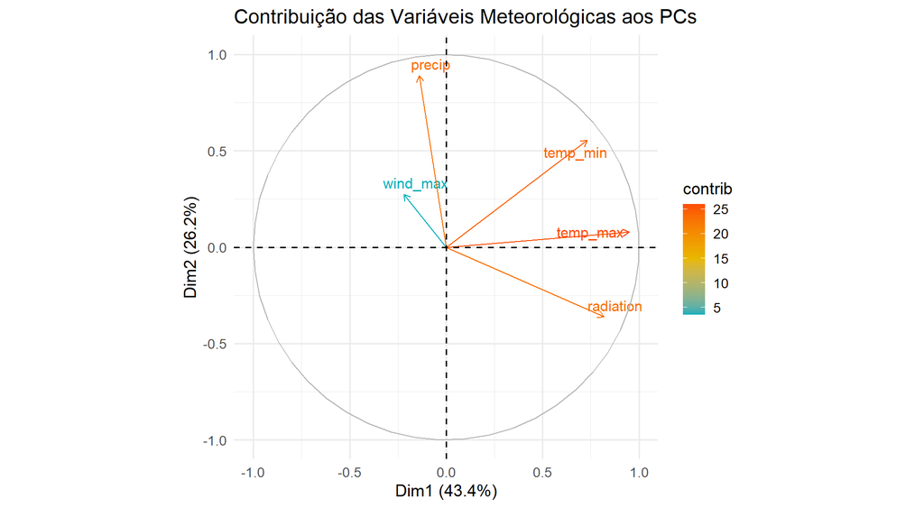

```r
fviz_pca_var(pca_sup, repel = TRUE,
             col.var       = "contrib",
             gradient.cols = c("#00AFBB","#E7B800","#FC4E07"),
             title = "Contribuição das Variáveis Meteorológicas aos PCs") +
  theme_minimal(base_size = 13)
```

**Tip**

**Por que ajustar o PCA apenas no treino?** O PCA aprende uma matriz de rotação `Phi`. Se for ajustado no dataset completo, os autovetores são influenciados pelos padrões do período de teste — leakage sutil mas real. `predict(pca_sup, X_test)` aplica a rotação aprendida no treino aos dados de teste sem reajustar nenhum parâmetro.

## 2.6 Projeção e Engenharia de Features

**Ver código**

```r
Z_train <- as.data.frame(predict(pca_sup, X_train))
Z_test  <- as.data.frame(predict(pca_sup, X_test))

# Unir cronologicamente ANTES de criar lags
# (garante que os lags no início do teste usem os últimos dias do treino)
Z_all <- bind_rows(
  Z_train |> mutate(date = train_raw$date, temp_mean = train_raw$temp_mean,
                    temp_max = train_raw$temp_max),
  Z_test  |> mutate(date = test_raw$date,  temp_mean = test_raw$temp_mean,
                    temp_max = test_raw$temp_max)
) |> arrange(date)
```

**Ver código**

```r
n_pcs <- 3

Z_model <- Z_all |>
  mutate(
    across(
      paste0("PC", seq_len(n_pcs)),
      list(lag1 = \(x) lag(x, 1), lag7 = \(x) lag(x, 7)),
      .names = "{.col}_{.fn}"
    ),
    temp_lag1 = lag(temp_mean, 1),
    month     = month(date),
    doy       = yday(date),
    target    = lead(temp_mean, 1)   # temperatura de AMANHÃ
  ) |>
  drop_na()

feat_names <- setdiff(names(Z_model),
                      c("date","temp_mean","temp_max","target",
                        paste0("PC", seq_len(n_pcs))))

cat("Features do modelo:\n")
```

```
Features do modelo:
```

**Ver código**

```r
print(feat_names)
```

```
 [1] "PC4"       "PC5"       "PC1_lag1"  "PC1_lag7"  "PC2_lag1"  "PC2_lag7"
 [7] "PC3_lag1"  "PC3_lag7"  "temp_lag1" "month"     "doy"
```

**Ver código**

```r
cat("\nTotal de observações:", nrow(Z_model), "\n")
```

```
Total de observações: 16429
```

| Feature | O que captura |
| --- | --- |
| `PC1_lag1`, `PC2_lag1`, `PC3_lag1` | Padrão meteorológico de **ontem** |
| `PC1_lag7`, `PC2_lag7`, `PC3_lag7` | Padrão de **uma semana atrás** |
| `temp_lag1` | Temperatura média de **ontem** — preditor mais direto |
| `month` | Sazonalidade mensal discreta |
| `doy` | Dia do ano — curva sazonal suave |

`target = lead(temp_mean, 1)` desloca a série 1 posição: na linha do dia $t$, o alvo é a temperatura do dia $t+1$.

## 2.7 Split Final e Métricas

**Ver código**

```r
train_df <- Z_model |> filter(date <  cutoff)
test_df  <- Z_model |> filter(date >= cutoff)

cat(sprintf("Treino final: %d obs | Teste final: %d obs\n",
            nrow(train_df), nrow(test_df)))
```

```
Treino final: 15699 obs | Teste final: 730 obs
```

**Ver código**

```r
rmse <- function(pred, real) sqrt(mean((pred - real)^2))
mae  <- function(pred, real) mean(abs(pred - real))
r2   <- function(pred, real) cor(pred, real)^2
```

| Métrica | Fórmula | Interpretação |
| --- | --- | --- |
| **RMSE** | $\sqrt{\frac{1}{n}\sum(y_i-\hat y_i)^2}$ | Erro típico em °C — penaliza grandes erros |
| **MAE** | $\frac{1}{n}\sum\|y_i-\hat y_i\|$ | Erro médio absoluto — robusto a outliers |
| **R²** | $\text{cor}(y,\hat y)^2$ | Proporção da variância do alvo explicada |

## 2.8 Modelo 1 — Regressão Linear (Baseline)

**Ver código**

```r
lm_formula <- reformulate(feat_names, response = "target")
lm_fit     <- lm(lm_formula, data = train_df)
pred_lm    <- predict(lm_fit, newdata = test_df)

cat(sprintf("LM  — RMSE: %.3f °C | MAE: %.3f °C | R²: %.4f\n",
            rmse(pred_lm, test_df$target),
            mae(pred_lm,  test_df$target),
            r2(pred_lm,   test_df$target)))
```

```
LM  — RMSE: 2.306 °C | MAE: 1.790 °C | R²: 0.4990
```

A regressão linear é o **modelo de referência**: sem hiperparâmetros, sem risco de overfitting, totalmente interpretável pelos coeficientes. Um RMSE de 1.5–2.5 °C já é razoável para previsão de 1 dia à frente em clima tropical.

## 2.9 Modelo 2 — Random Forest (ranger)

**Ver código**

```r
model_cols <- c(feat_names, "target")

rf_fit  <- ranger(target ~ .,
                  data        = train_df |> select(all_of(model_cols)),
                  num.trees   = 500,
                  importance  = "impurity",
                  num.threads = n_cores)
pred_rf <- predict(rf_fit,
                   data = test_df |> select(all_of(feat_names)))$predictions

cat(sprintf("RF  — RMSE: %.3f °C | MAE: %.3f °C | R²: %.4f\n",
            rmse(pred_rf, test_df$target),
            mae(pred_rf,  test_df$target),
            r2(pred_rf,   test_df$target)))
```

```
RF  — RMSE: 2.201 °C | MAE: 1.664 °C | R²: 0.5630
```

O Random Forest captura relações **não-lineares** — por exemplo, o efeito de `temp_lag1` no verão pode ser diferente do inverno sem interações explícitas na fórmula.

## 2.10 Modelo 3 — Ensemble (LM + RF)

**Ver código**

```r
pred_ens <- (pred_lm + pred_rf) / 2

cat(sprintf("ENS — RMSE: %.3f °C | MAE: %.3f °C | R²: %.4f\n",
            rmse(pred_ens, test_df$target),
            mae(pred_ens,  test_df$target),
            r2(pred_ens,   test_df$target)))
```

```
ENS — RMSE: 2.151 °C | MAE: 1.664 °C | R²: 0.5763
```

O ensemble cancela erros correlacionados negativamente entre LM e RF:

$$\text{RMSE}_\text{ensemble} \leq \frac{\text{RMSE}_{LM} + \text{RMSE}_{RF}}{2}$$

A igualdade só vale se os dois modelos erram nos mesmos dias — o que raramente ocorre.

## 2.11 Intervalos de Incerteza — Quantile RF

**Ver código**

```r
rf_q <- ranger(target ~ .,
               data        = train_df |> select(all_of(model_cols)),
               num.trees   = 500,
               quantreg    = TRUE,
               num.threads = n_cores)

q_pred <- predict(rf_q,
                  data      = test_df |> select(all_of(feat_names)),
                  type      = "quantiles",
                  quantiles = c(0.10, 0.50, 0.90))$predictions

colnames(q_pred) <- c("q10","q50","q90")

coverage <- mean(test_df$target >= q_pred[,"q10"] &
                   test_df$target <= q_pred[,"q90"])

cat(sprintf("Cobertura 10%%–90%%: %.1f%% (esperado ~80%%)\n", coverage * 100))
```

```
Cobertura 10%–90%: 84.4% (esperado ~80%)
```

**Ver código**

```r
cat(sprintf("Amplitude média: %.2f °C\n",
            mean(q_pred[,"q90"] - q_pred[,"q10"])))
```

```
Amplitude média: 5.71 °C
```

Com `quantreg = TRUE`, o ranger armazena as distribuições de folha e produz **quantis de predição** — análogo ao spread de ensemble do ECMWF. O intervalo [q10, q90] deve conter ~80% dos valores reais para ser bem calibrado.

## 2.12 Resultados

### 2.12.1 Comparação de modelos

**Ver código**

```r
results_sup <- tibble(
  Modelo = c("LM — PCs + lags", "RF — PCs + lags", "Ensemble (LM + RF)"),
  RMSE   = c(rmse(pred_lm, test_df$target),
             rmse(pred_rf, test_df$target),
             rmse(pred_ens,test_df$target)),
  MAE    = c(mae(pred_lm,  test_df$target),
             mae(pred_rf,  test_df$target),
             mae(pred_ens, test_df$target)),
  R2     = c(r2(pred_lm,  test_df$target),
             r2(pred_rf,  test_df$target),
             r2(pred_ens, test_df$target))
) |>
  mutate(across(where(is.numeric), \(x) round(x, 4))) |>
  arrange(RMSE)

results_sup |>
  knitr::kable(caption = "Métricas no conjunto de teste (2023–2024)")
```

Métricas no conjunto de teste (2023–2024)

| Modelo | RMSE | MAE | R2 |
| --- | --- | --- | --- |
| Ensemble (LM + RF) | 2.1507 | 1.6643 | 0.5763 |
| RF — PCs + lags | 2.2011 | 1.6636 | 0.5630 |
| LM — PCs + lags | 2.3064 | 1.7900 | 0.4990 |

**ImportantConclusão — melhor modelo supervisionado**

Com base nas métricas acima no conjunto de teste (2023–2024), o **Ensemble (LM + RF)** é o modelo de melhor desempenho, com **RMSE = 2.151 °C**, **MAE = 1.664 °C** e **R² = 0.5763**. Isso representa uma redução de 6.8% no RMSE em relação ao pior modelo da tabela.

O ensemble vence porque LM e RF erram em direções parcialmente independentes — a média cancela parte do ruído idiossincrático de cada modelo. Este é o mesmo princípio do multi-model ensemble meteorológico (IFS + GFS + ICON) que supera consistentemente qualquer modelo individual em previsão operacional.

### 2.12.2 Série temporal de previsão

**Ver código**

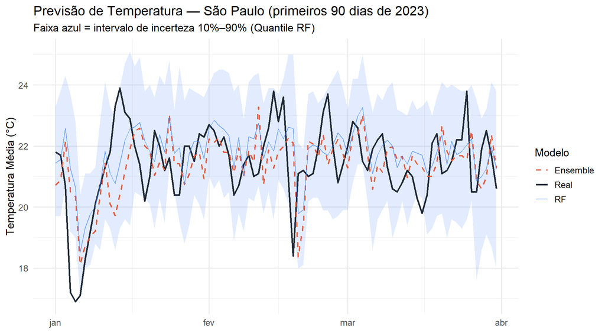

Figure 5: Primeiros 90 dias de teste. A faixa azul é o intervalo de incerteza 10%–90% do Quantile RF. Espera-se que ~80% da linha preta (real) fique dentro da faixa.

```r
results_df <- test_df |>
  select(date, target) |>
  mutate(LM = pred_lm, RF = pred_rf, Ensemble = pred_ens,
         q10 = q_pred[,"q10"], q90 = q_pred[,"q90"])

results_df |>
  slice_head(n = 90) |>
  ggplot(aes(date)) +
  geom_ribbon(aes(ymin = q10, ymax = q90), fill = "#3B82F6", alpha = 0.15) +
  geom_line(aes(y = target,   color = "Real"),     linewidth = 1.0) +
  geom_line(aes(y = Ensemble, color = "Ensemble"), linewidth = 0.8, linetype = "dashed") +
  geom_line(aes(y = RF,       color = "RF"),       linewidth = 0.5, alpha = 0.7) +
  scale_color_manual(values = c("Real"="#1F2937","Ensemble"="#E8583E","RF"="#3B82F6")) +
  labs(title    = "Previsão de Temperatura — São Paulo (primeiros 90 dias de 2023)",
       subtitle = "Faixa azul = intervalo de incerteza 10%–90% (Quantile RF)",
       x = NULL, y = "Temperatura Média (°C)", color = "Modelo") +
  theme_minimal(base_size = 13)
```

### 2.12.3 Predito vs Real

**Ver código**

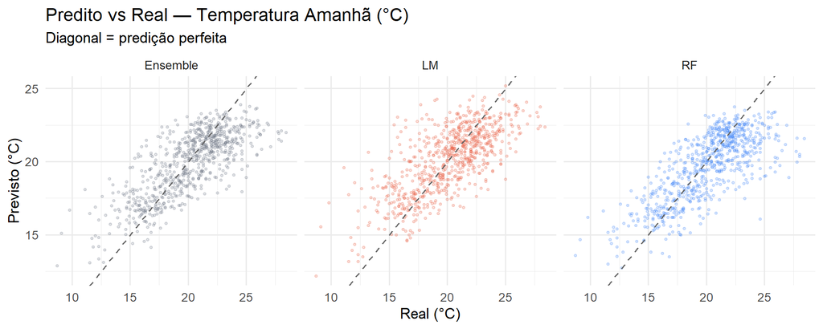

Figure 6: Scatter predito × real para os 3 modelos. Pontos na diagonal = predição perfeita. Dispersão fora da diagonal = erros.

```r
results_df |>
  pivot_longer(c(LM, RF, Ensemble), names_to = "Modelo", values_to = "Predito") |>
  ggplot(aes(target, Predito, color = Modelo)) +
  geom_point(alpha = 0.2, size = 0.9) +
  geom_abline(slope = 1, intercept = 0, linetype = "dashed", color = "gray40") +
  facet_wrap(~Modelo) +
  scale_color_manual(values = c("#6B7280","#E8583E","#3B82F6")) +
  labs(title = "Predito vs Real — Temperatura Amanhã (°C)",
       subtitle = "Diagonal = predição perfeita",
       x = "Real (°C)", y = "Previsto (°C)") +
  theme_minimal(base_size = 13) +
  theme(legend.position = "none")
```

### 2.12.4 Resíduos e importância das features

**Ver código**

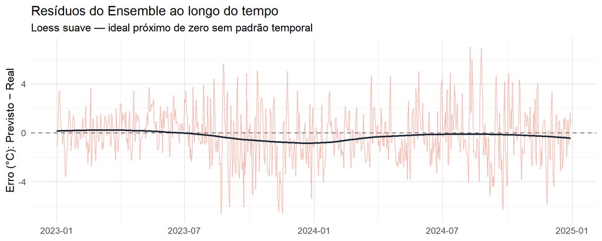

Figure 7

```r
results_df |>
  mutate(residuo = Ensemble - target) |>
  ggplot(aes(date, residuo)) +
  geom_hline(yintercept = 0, linetype = "dashed", color = "gray50") +
  geom_line(alpha = 0.4, color = "#E8583E", linewidth = 0.4) +
  geom_smooth(method = "loess", se = FALSE, color = "#1F2937", linewidth = 0.9) +
  labs(title = "Resíduos do Ensemble ao longo do tempo",
       subtitle = "Loess suave — ideal próximo de zero sem padrão temporal",
       x = NULL, y = "Erro (°C): Previsto − Real") +
  theme_minimal(base_size = 13)
```

**Ver código**

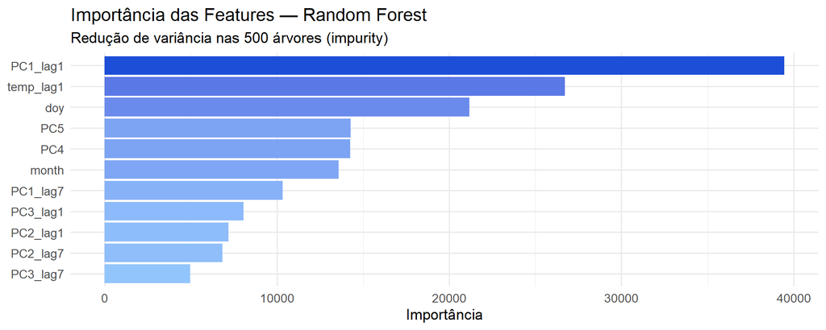

```r
rf_fit$variable.importance |>
  enframe(name = "Feature", value = "Importance") |>
  arrange(desc(Importance)) |>
  ggplot(aes(reorder(Feature, Importance), Importance, fill = Importance)) +
  geom_col() +
  coord_flip() +
  scale_fill_gradient(low = "#93C5FD", high = "#1D4ED8") +
  labs(title    = "Importância das Features — Random Forest",
       subtitle = "Redução de variância nas 500 árvores (impurity)",
       x = NULL, y = "Importância") +
  theme_minimal(base_size = 13) +
  theme(legend.position = "none")
```

**Ver código**

```r
stopCluster(cl)
registerDoSEQ()
cat("Cluster paralelo encerrado.\n")
```

```
Cluster paralelo encerrado.
```

# 3 Parte II — Abordagem Não-Supervisionada

## 3.1 Dados — Open-Meteo ERA5 (12 Cidades, Diário → Mensal)

### 3.1.1 Por que uma abordagem diferente?

Na Parte I havia um **alvo claro** (temperatura de amanhã) e dados diários de um único ponto. Aqui não existe alvo — queremos descobrir estrutura intrínseca nos dados climáticos de múltiplas cidades, respondendo:

> *Quais cidades têm perfis climáticos similares? Existem zonas climáticas naturais no Brasil?*

Isso é **aprendizado não-supervisionado**: o PCA e o clustering são os modelos em si, não ferramentas intermediárias.

### 3.1.2 Carregamento — CSV pré-coletado

Os dados foram coletados pelo script `fetch_data.py`, que busca dados diários do Open-Meteo ERA5 para cada cidade em janelas de 2 anos, persiste cada chunk em `data/chunks/` (permitindo retomada incremental após interrupção) e, na etapa de combinação, agrega tudo para resolução mensal. O CSV resultante é lido diretamente aqui.

**Ver código**

```r
cities <- tribble(
  ~city,             ~region,         ~lon,    ~lat,
  "Manaus",          "Norte",        -60.02,  -3.10,
  "Belém",           "Norte",        -48.48,  -1.46,
  "Recife",          "Nordeste",     -34.88,  -8.05,
  "Fortaleza",       "Nordeste",     -38.54,  -3.72,
  "Salvador",        "Nordeste",     -38.51, -12.97,
  "Brasília",        "Centro-Oeste", -47.93, -15.78,
  "Cuiabá",          "Centro-Oeste", -56.10, -15.60,
  "São Paulo",       "Sudeste",      -46.63, -23.55,
  "Rio de Janeiro",  "Sudeste",      -43.18, -22.91,
  "Belo Horizonte",  "Sudeste",      -43.94, -19.92,
  "Porto Alegre",    "Sul",          -51.23, -30.03,
  "Curitiba",        "Sul",          -49.27, -25.43
)
```

**Ver código**

```r
climate_df <- read_csv("data/brazil_monthly.csv", show_col_types = FALSE) |>
  left_join(cities |> select(city, lon, lat), by = "city") |>
  mutate(
    date       = make_date(year, month, 1),
    temp_range = temp_max - temp_min,
    season     = case_when(
      month %in% c(12,  1,  2) ~ "Verão",
      month %in% c( 3,  4,  5) ~ "Outono",
      month %in% c( 6,  7,  8) ~ "Inverno",
      month %in% c( 9, 10, 11) ~ "Primavera"
    ),
    season = factor(season, levels = c("Verão","Outono","Inverno","Primavera"))
  )

cat(sprintf("Dataset: %d linhas | %d cidades | %d anos\n",
            nrow(climate_df),
            n_distinct(climate_df$city),
            n_distinct(climate_df$year)))
```

```
Dataset: 6480 linhas | 12 cidades | 45 anos
```

**Ver código**

```r
loaded_cities <- unique(climate_df$city)
missing_cities <- setdiff(cities$city, loaded_cities)
if (length(missing_cities) > 0) {
  cat("⚠ Cidades não carregadas:", paste(missing_cities, collapse = ", "), "\n")
} else {
  cat("✓ Todas as 12 cidades presentes no CSV.\n")
}
```

```
✓ Todas as 12 cidades presentes no CSV.
```

**Ver código**

```r
glimpse(climate_df)
```

```
Rows: 6,480
Columns: 15
$ city       <chr> "Belo Horizonte", "Belo Horizonte", "Belo Horizonte", "Belo…
$ region     <chr> "Sudeste", "Sudeste", "Sudeste", "Sudeste", "Sudeste", "Sud…
$ year       <dbl> 1980, 1980, 1980, 1980, 1980, 1980, 1980, 1980, 1980, 1980,…
$ month      <dbl> 1, 2, 3, 4, 5, 6, 7, 8, 9, 10, 11, 12, 1, 2, 3, 4, 5, 6, 7,…
$ temp       <dbl> 21.13226, 21.50000, 21.67742, 19.93333, 18.68710, 16.64667,…
$ temp_max   <dbl> 25.07419, 25.66552, 27.01935, 24.42667, 23.95161, 21.54000,…
$ temp_min   <dbl> 18.13226, 17.97241, 16.56774, 16.36667, 13.98710, 12.29000,…
$ precip     <dbl> 257.2, 163.1, 50.4, 125.8, 4.4, 20.5, 1.3, 9.5, 47.2, 97.4,…
$ wind       <dbl> 11.216129, 11.489655, 9.993548, 11.486667, 10.374194, 11.47…
$ radiation  <dbl> 18.10097, 19.75241, 22.36516, 15.57533, 15.48194, 11.85300,…
$ lon        <dbl> -43.94, -43.94, -43.94, -43.94, -43.94, -43.94, -43.94, -43…
$ lat        <dbl> -19.92, -19.92, -19.92, -19.92, -19.92, -19.92, -19.92, -19…
$ date       <date> 1980-01-01, 1980-02-01, 1980-03-01, 1980-04-01, 1980-05-01…
$ temp_range <dbl> 6.941935, 7.693103, 10.451613, 8.060000, 9.964516, 9.250000…
$ season     <fct> Verão, Verão, Outono, Outono, Outono, Inverno, Inverno, Inv…
```

**Note**

**Pipeline de dados separado:** o script `fetch_data.py` coleta dados diários do Open-Meteo ERA5 para as 12 cidades em chunks de 2 anos (cache incremental em `data/chunks/`), agrega para resolução mensal (média para temperaturas, soma para precipitação) e salva em `data/brazil_monthly.csv`. Isso garante que o QMD renderiza em segundos sem depender de chamadas de API.

## 3.2 Análise Exploratória Multi-Cidades

**Ver código**

```r
cities_sel <- c("Manaus","Recife","Brasília","São Paulo","Porto Alegre")
pal_set2   <- RColorBrewer::brewer.pal(5, "Set2")

p_t <- climate_df |>
  filter(city %in% cities_sel) |>
  ggplot(aes(date, temp, color = city,
             text = paste0(city, "<br>", format(date, "%b %Y"),
                           "<br>Temp: ", round(temp, 1), " °C"))) +
  geom_line(alpha = 0.8, linewidth = 0.5) +
  scale_color_manual(values = setNames(pal_set2, cities_sel)) +
  scale_x_date(date_breaks = "5 years", date_labels = "%Y") +
  labs(title = "Temperatura Mensal — Brasil (Open-Meteo ERA5)",
       x = NULL, y = "°C", color = "Cidade") +
  theme_minimal(base_size = 12) +
  theme(legend.position = "bottom")

p_p <- climate_df |>
  filter(city %in% cities_sel) |>
  ggplot(aes(date, precip, color = city,
             text = paste0(city, "<br>", format(date, "%b %Y"),
                           "<br>Precip: ", round(precip, 1), " mm"))) +
  geom_line(alpha = 0.8, linewidth = 0.5) +
  scale_color_manual(values = setNames(pal_set2, cities_sel)) +
  scale_x_date(date_breaks = "5 years", date_labels = "%Y") +
  labs(title = "Precipitação Mensal — Brasil (Open-Meteo ERA5)",
       x = NULL, y = "mm/mês", color = "Cidade") +
  theme_minimal(base_size = 12) +
  theme(legend.position = "bottom")

subplot(
  ggplotly(p_t, tooltip = "text") |> layout(showlegend = TRUE),
  ggplotly(p_p, tooltip = "text") |> layout(showlegend = FALSE),
  nrows = 2, shareX = TRUE, titleY = TRUE, heights = c(0.5, 0.5)
) |>
  layout(
    title = list(text = "Temperatura e Precipitação Mensais — 5 Cidades Representativas",
                 font = list(size = 14)),
    margin = list(t = 60)
  )
```

[interactive chart not shown]

Figure 9: Séries de temperatura e precipitação para 5 cidades representativas. Passe o mouse sobre as linhas para ver valores exatos. Use a legenda para mostrar/ocultar cidades.

**Ver código**

```r
seasonal_long <- climate_df |>
  group_by(region, month) |>
  summarise(temp_m   = mean(temp,   na.rm = TRUE),
            precip_m = mean(precip, na.rm = TRUE), .groups = "drop") |>
  mutate(mes_abr = month.abb[month])

pal_set1 <- RColorBrewer::brewer.pal(n_distinct(seasonal_long$region), "Set1")
regions  <- unique(seasonal_long$region)

make_seasonal_trace <- function(reg, y_col, y_label, showlegend) {
  d <- seasonal_long |> filter(region == reg)
  list(
    x           = d$mes_abr,
    y           = d[[y_col]],
    type        = "scatter",
    mode        = "lines+markers",
    name        = reg,
    legendgroup = reg,
    showlegend  = showlegend,
    hovertemplate = paste0("<b>", reg, "</b><br>Mês: %{x}<br>",
                           y_label, ": %{y:.1f}<extra></extra>"),
    line        = list(color = pal_set1[which(regions == reg)], width = 2),
    marker      = list(color = pal_set1[which(regions == reg)], size = 6)
  )
}

traces_temp   <- lapply(regions, make_seasonal_trace, "temp_m",   "Temp (°C)",   TRUE)
traces_precip <- lapply(regions, make_seasonal_trace, "precip_m", "Precip (mm)", FALSE)

plot_ly() |>
  (\(p) {
    for (tr in traces_temp)   p <- add_trace(p, x=tr$x, y=tr$y, type=tr$type,
      mode=tr$mode, name=tr$name, legendgroup=tr$legendgroup,
      showlegend=tr$showlegend, hovertemplate=tr$hovertemplate,
      line=tr$line, marker=tr$marker, xaxis="x", yaxis="y")
    for (tr in traces_precip) p <- add_trace(p, x=tr$x, y=tr$y, type=tr$type,
      mode=tr$mode, name=tr$name, legendgroup=tr$legendgroup,
      showlegend=tr$showlegend, hovertemplate=tr$hovertemplate,
      line=tr$line, marker=tr$marker, xaxis="x2", yaxis="y2")
    p
  })() |>
  layout(
    title  = list(text = "Perfil Sazonal Médio por Região", font = list(size = 14)),
    xaxis  = list(title = "Mês", categoryorder = "array",
                  categoryarray = month.abb, domain = c(0, 0.47)),
    yaxis  = list(title = "Temperatura (°C)"),
    xaxis2 = list(title = "Mês", categoryorder = "array",
                  categoryarray = month.abb, domain = c(0.53, 1)),
    yaxis2 = list(title = "Precipitação (mm)"),
    legend = list(orientation = "h", y = -0.15),
    margin = list(t = 50)
  )
```

[interactive chart not shown]

Figure 10: Ciclo sazonal médio por região. Passe o mouse sobre os pontos para ver valores. Clique nas regiões na legenda para mostrar/ocultar.

## 3.3 PCA Não-Supervisionado — Padrões Climáticos entre Cidades

### 3.3.1 Diferença conceitual em relação à Parte I

Na Parte I, o PCA era uma **ferramenta** de redução de dimensionalidade a serviço de um alvo externo (temperatura amanhã). Aqui, o PCA **é o modelo** — o resultado final são os eixos de variação que separam climaticamente as 12 cidades.

### 3.3.2 Perfis médios por cidade

**Ver código**

```r
city_profiles <- climate_df |>
  group_by(city, region) |>
  summarise(
    temp_mean  = mean(temp,       na.rm = TRUE),
    temp_range = mean(temp_range, na.rm = TRUE),
    precip     = mean(precip,     na.rm = TRUE),
    radiation  = mean(radiation,  na.rm = TRUE),
    wind       = mean(wind,       na.rm = TRUE),
    .groups    = "drop"
  )

city_profiles |>
  select(-region) |>
  mutate(across(where(is.numeric), ~round(., 1))) |>
  knitr::kable(caption = "Perfil climático médio por cidade (1980–2024)")
```

Perfil climático médio por cidade (1980–2024)

| city | temp_mean | temp_range | precip | radiation | wind |
| --- | --- | --- | --- | --- | --- |
| Belo Horizonte | 20.5 | 9.6 | 102.3 | 18.6 | 12.4 |
| Belém | 26.6 | 5.8 | 172.4 | 18.6 | 13.4 |
| Brasília | 21.3 | 9.1 | 115.0 | 19.3 | 13.7 |
| Cuiabá | 26.1 | 9.0 | 118.2 | 19.0 | 11.9 |
| Curitiba | 17.4 | 7.8 | 127.2 | 15.2 | 15.8 |
| Fortaleza | 26.6 | 4.8 | 84.7 | 20.9 | 22.9 |
| Manaus | 26.5 | 5.6 | 218.5 | 16.9 | 9.8 |
| Porto Alegre | 19.5 | 8.6 | 128.5 | 16.1 | 17.1 |
| Recife | 25.8 | 4.8 | 81.6 | 19.4 | 17.9 |
| Rio de Janeiro | 23.5 | 7.0 | 133.6 | 17.0 | 11.8 |
| Salvador | 25.2 | 3.3 | 104.0 | 19.7 | 20.2 |
| São Paulo | 19.5 | 8.3 | 110.0 | 16.9 | 16.5 |

### 3.3.3 Padronização e ajuste do PCA

**Ver código**

```r
pca_data <- city_profiles |> column_to_rownames("city") |> select(-region)

X_uns <- scale(pca_data, center = TRUE, scale = TRUE)

pca_uns <- prcomp(X_uns)
pca_uns$rotation <- -pca_uns$rotation
pca_uns$x        <- -pca_uns$x

cat("Variância acumulada:\n")
```

```
Variância acumulada:
```

**Ver código**

```r
print(round(cumsum(pca_uns$sdev^2) / sum(pca_uns$sdev^2), 3))
```

```
[1] 0.492 0.811 0.962 0.986 1.000
```

**Ver código**

```r
cat("\nCargas (Phi) — 3 primeiros PCs:\n")
```

```
Cargas (Phi) — 3 primeiros PCs:
```

**Ver código**

```r
print(round(pca_uns$rotation[, 1:3], 3))
```

```
              PC1    PC2    PC3
temp_mean  -0.418 -0.556 -0.242
temp_range  0.476  0.312 -0.583
precip      0.311 -0.646  0.246
radiation  -0.539 -0.024 -0.576
wind       -0.459  0.419  0.458
```

**Ver código**

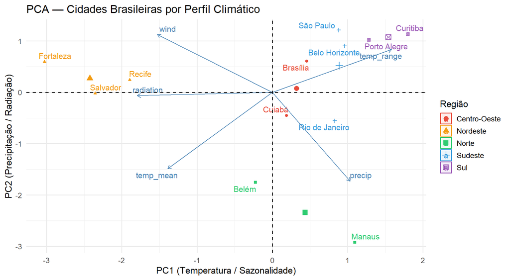

```r
fviz_pca_biplot(
  pca_uns, repel = TRUE,
  col.ind      = city_profiles$region,
  palette      = c("#E74C3C","#F39C12","#2ECC71","#3498DB","#9B59B6"),
  addEllipses  = TRUE, ellipse.level = 0.70,
  legend.title = "Região",
  title = "PCA — Cidades Brasileiras por Perfil Climático",
  xlab  = "PC1 (Temperatura / Sazonalidade)",
  ylab  = "PC2 (Precipitação / Radiação)"
) + theme_minimal(base_size = 13)
```

## 3.4 Clustering — Zonas Climáticas Automáticas

### 3.4.1 Escolha do número de clusters

**Ver código**

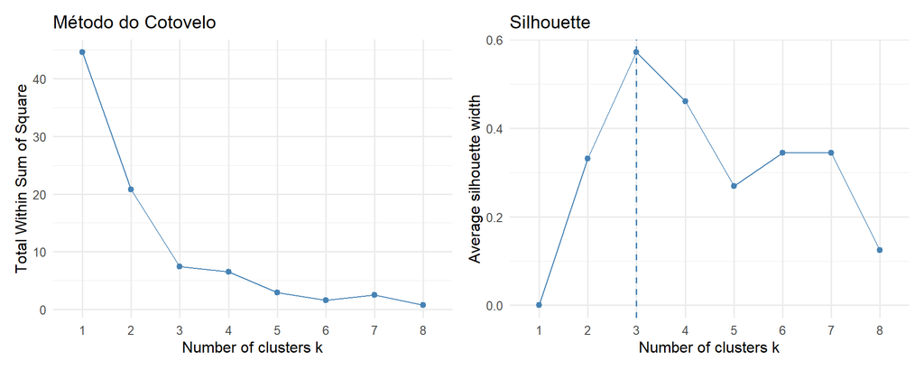

Figure 12: Critérios de escolha do k: elbow (joelho na curva WSS) e silhouette (máximo = melhor separação). Ambos tipicamente apontam k=3 para o Brasil.

```r
pc_scores <- as.data.frame(pca_uns$x[, 1:2])
k_max <- min(8, nrow(pc_scores) - 1)

p_elbow <- fviz_nbclust(pc_scores, kmeans, method = "wss", k.max = k_max) +
  labs(title = "Método do Cotovelo") + theme_minimal(base_size = 12)

p_silh  <- fviz_nbclust(pc_scores, kmeans, method = "silhouette", k.max = k_max) +
  labs(title = "Silhouette") + theme_minimal(base_size = 12)

p_elbow + p_silh
```

### 3.4.2 K-Means (k = 3)

**Ver código**

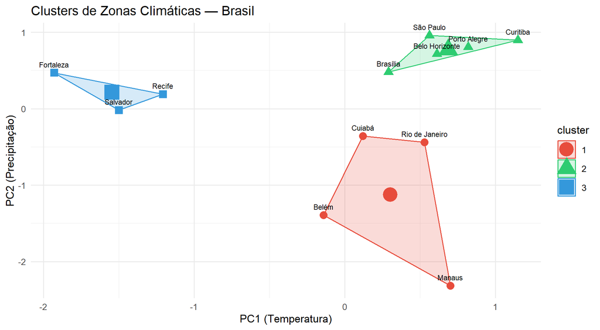

```r
set.seed(42)
k_centers <- min(3, nrow(pc_scores) - 1)
km <- kmeans(pc_scores, centers = k_centers, nstart = 25)
city_profiles$cluster <- as.factor(km$cluster)

fviz_cluster(km, data = pc_scores,
             palette = c("#E74C3C","#2ECC71","#3498DB"),
             geom = "point", ellipse.type = "convex", pointsize = 4,
             main = "Clusters de Zonas Climáticas — Brasil",
             xlab = "PC1 (Temperatura)", ylab = "PC2 (Precipitação)") +
  geom_text(aes(label = rownames(pc_scores)),
            size = 3, vjust = -1, check_overlap = TRUE) +
  theme_minimal(base_size = 13)
```

**Ver código**

```r
city_profiles |>
  group_by(cluster) |>
  summarise(
    Cidades         = paste(city, collapse = ", "),
    `Temp. Média`   = round(mean(temp_mean), 1),
    `Precip. Média` = round(mean(precip), 1),
    `Radiação Média` = round(mean(radiation), 1),
    N = n(), .groups = "drop"
  ) |>
  knitr::kable(caption = "Perfil médio de cada zona climática (K-Means)")
```

Perfil médio de cada zona climática (K-Means)

| cluster | Cidades | Temp. Média | Precip. Média | Radiação Média | N |
| --- | --- | --- | --- | --- | --- |
| 1 | Belém, Cuiabá, Manaus, Rio de Janeiro | 25.7 | 160.7 | 17.9 | 4 |
| 2 | Belo Horizonte, Brasília, Curitiba, Porto Alegre, São Paulo | 19.6 | 116.6 | 17.2 | 5 |
| 3 | Fortaleza, Recife, Salvador | 25.9 | 90.1 | 20.0 | 3 |

### 3.4.3 Clustering Hierárquico (Ward’s)

**Ver código**

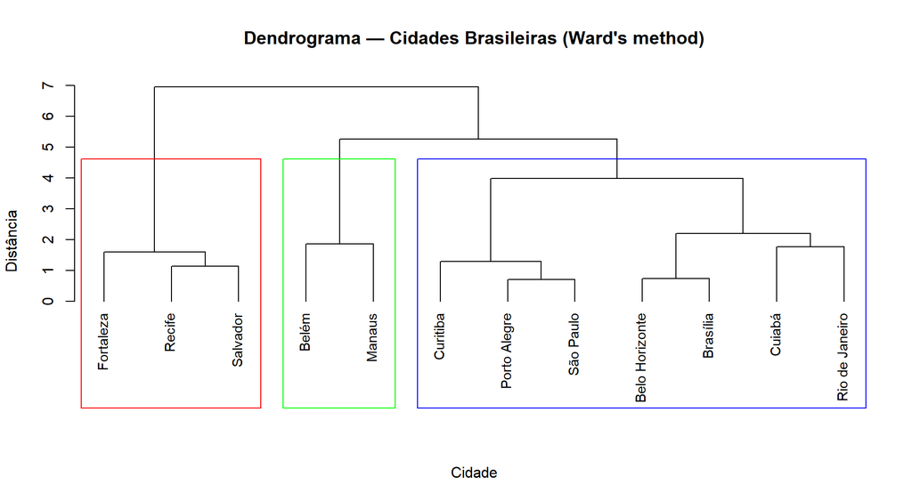

Figure 14: Dendrograma Ward’s: as caixas coloridas indicam o corte em k=3. O hierárquico não exige k a priori e é determinístico — ideal para validar o K-Means.

```r
dist_matrix <- dist(X_uns, method = "euclidean")
hclust_res  <- hclust(dist_matrix, method = "ward.D2")

plot(hclust_res, main = "Dendrograma — Cidades Brasileiras (Ward's method)",
     xlab = "Cidade", ylab = "Distância", sub = "", cex = 0.9, hang = -1)
rect.hclust(hclust_res, k = 3, border = c("red","green","blue"))
```

**Tip**

**K-Means vs Hierárquico:** K-Means é mais eficiente computacionalmente (essencial para n grande), mas requer k a priori e não é determinístico sem `set.seed`. Hierárquico é determinístico, permite visualizar a estrutura de fusão completa, mas tem complexidade O(n²) em memória — inviável para grandes datasets. Com 12 cidades, ambos são triviais; use os dois para cruzar a interpretação.

## 3.5 Decomposição de Séries Temporais

**Ver código**

```r
# Garantir que não há duplicatas city+yearmonth antes da conversão
climate_ts <- climate_df |>
  mutate(yearmonth = yearmonth(date)) |>
  group_by(city, yearmonth) |>
  summarise(across(c(temp, temp_max, temp_min, precip, wind, radiation, temp_range),
                   ~mean(.x, na.rm = TRUE)),
            region = first(region),
            season = first(season),
            .groups = "drop") |>
  as_tsibble(key = city, index = yearmonth) |>
  fill_gaps() |>                         # preenche meses faltantes com NA
  group_by_key() |>
  tidyr::fill(temp, temp_max, temp_min, precip, wind, radiation,
              temp_range, region, season, .direction = "downup") |>
  ungroup()

cat(sprintf("Tsibble: %d linhas | %d cidades | gaps preenchidos\n",
            nrow(climate_ts), n_distinct(climate_ts$city)))
```

```
Tsibble: 6480 linhas | 12 cidades | gaps preenchidos
```

**Ver código**

```r
cat(sprintf("NAs restantes em temp: %d\n", sum(is.na(climate_ts$temp))))
```

```
NAs restantes em temp: 0
```

O `tsibble` é o formato exigido pelo `fable`: um tibble com índice temporal (`yearmonth`) e chave de série (`city`). O índice define a frequência — aqui mensal (12 por ano).